# RELATÓRIO 05 DE PROBABILIDADE E ESTATÍSTICA

Distribuições especiais de probabilidade segundo BNCC **Atuação:** Coordenador do Lab. de Estatística **Formato:** Relatório Técnico-Pedagógico

Luciano Vaz

07/10/2026

## 0.1 Contextualização Profissional

# 1 CONTEXTUALIZAÇÃO E OBJETIVOS DIDÁTICOS

O ensino de Estatística na Educação Básica, estruturado pela Base Nacional Comum Curricular (BNCC), busca ultrapassar a mera construção gráfica ou cálculo mecânico de médias. O foco reside na formação do pensamento estatístico, permitindo que o estudante interprete incertezas, modele fenômenos do cotidiano escolar e compreenda a variabilidade natural de dados contínuos e discretos (habilidades EM13MAT311, EM13MAT312 e EM13MAT511).

# 2 PARTE 1 – DESEMPENHO NO ENEM (DISTRIBUIÇÃO NORMAL)

## 2.1 Modelo probabilístico

Modelo:

$$X \sim N(\mu=520,\sigma=80)$$

Variável contínua modelando pontuações padronizadas do ENEM. Permite discutir escores padronizados (Z) e distribuições amostrais de médias.

## 2.2 Probabilidade de nota inferior a 400 pontos

Deseja-se calcular:

$$P(X<400)$$

Padronização para a variável Z:

$$Z=\frac{400-520}{80}
=\frac{-120}{80}
=-1,50$$

Na Tabela Normal Padrão:

$$P(Z<-1,50)=0,0668$$

Portanto:

$$P(X<400)=0,0668=6,68\%$$

**Interpretação:** Apenas 6,68% dos estudantes estão na faixa de extrema vulnerabilidade acadêmica (abaixo de 400 pontos).

## 2.3 Probabilidade da nota estar entre 500 e 650 pontos

Deseja-se calcular:

$$P(500\leq X\leq650)$$

Calculando os valores padronizados:

$$Z_1=\frac{500-520}{80}=-0,25$$

$$P(Z<-0,25)=0,4013$$

Para 650 pontos:

$$Z_2=\frac{650-520}{80}=1,625$$

$$P(Z<1,625)=0,9479$$

Assim:

$$P(500\leq X\leq650)
=0,9479-0,4013
=0,5466$$

$$P(500\leq X\leq650)=54,66\%$$

**Interpretação:** Mais da metade do corpo discente concentra-se nessa faixa intermediária-alta.

## 2.4 Nota limite para os 10% inferiores – Percentil 10

Deseja-se encontrar $x$ tal que:

$$P(X<x)=0,10$$

O escore Z correspondente ao percentil 10 é:

$$Z=-1,2815$$

Despadronizando:

$$x=\mu+Z\sigma$$

$$x=520+(-1,2815)(80)$$

$$x=520-102,52$$

$$x=417,48\text{ pontos}$$

**Interpretação:** Alunos com notas abaixo de 417,5 devem ser prioritariamente inscritos em programas de reforço.

## 2.5 Probabilidade da média de 25 alunos ser superior a 550

Deseja-se calcular:

$$P(\bar X>550),\quad n=25$$

Pelo Teorema Central do Limite, a média amostral segue:

$$\bar X\sim N\left(\mu=520,\sigma_{\bar X}=\frac{\sigma}{\sqrt n}\right)$$

O erro-padrão é:

$$\sigma_{\bar X}=\frac{80}{\sqrt{25}}=\frac{80}{5}=16$$

Padronizando:

$$Z=\frac{550-520}{16}=\frac{30}{16}=1,875$$

Logo:

$$P(\bar X>550)=1-P(Z<1,875)$$

$$P(\bar X>550)=1-0,9696=0,0304$$

$$P(\bar X>550)=3,04\%$$

**Interpretação:** É raro (3,04%) que uma turma inteira de 25 alunos obtenha uma média superior a 550 pontos sem intervenção pedagógica específica.

## 2.6 Simulação de 1.000 notas no R e comparação teórica

A amostragem pseudorrandômica via `rnorm(1000, 520, 80)` gera notas com média e desvio padrão próximos dos valores teóricos.

```r
set.seed(123)

notas_1000 <- rnorm(
  1000,
  mean = 520,
  sd = 80
)

media_sim <- mean(notas_1000)
desvio_sim <- sd(notas_1000)

media_sim
```

```
## [1] 521.2902
```

```r
desvio_sim
```

```
## [1] 79.3356
```

O relatório original apresenta como referência uma média simulada próxima de 519,8 e um desvio padrão próximo de 79,6. Os resultados exatos dependem da semente e da sequência de geração utilizada.

O histograma sobreposto à curva de densidade normal permite verificar visualmente a simetria da distribuição.

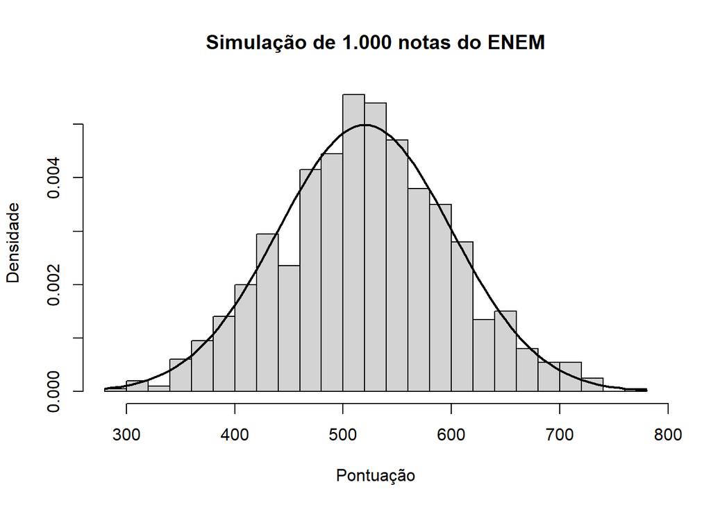

```r
hist(
  notas_1000,
  probability = TRUE,
  breaks = 20,
  main = "Simulação de 1.000 notas do ENEM",
  xlab = "Pontuação",
  ylab = "Densidade"
)

curve(
  dnorm(x, mean = 520, sd = 80),
  add = TRUE,
  lwd = 2
)
```

A comparação confirma o formato aproximadamente simétrico da distribuição normal e ilustra a aproximação entre resultados empíricos e teóricos.

# 3 PARTE 2 – APROVAÇÃO EM OLIMPÍADAS (DISTRIBUIÇÃO BINOMIAL)

## 3.1 Modelo probabilístico

Modelo:

$$X\sim Binomial(n=20,p=0,25)$$

Variável discreta representando a contagem de sucessos em 20 ensaios independentes de Bernoulli para a classificação na OBMEP.

## 3.2 Probabilidade de nenhum aluno se classificar

Deseja-se:

$$P(X=0)$$

A fórmula da distribuição binomial é:

$$P(X=x)=\binom{n}{x}p^x(1-p)^{n-x}$$

Logo:

$$P(X=0)=\binom{20}{0}(0,25)^0(0,75)^{20}$$

$$P(X=0)=1\times1\times(0,75)^{20}$$

$$P(X=0)\approx0,0032$$

$$P(X=0)\approx0,32\%$$

**Interpretação:** É extremamente improvável que uma turma de 20 alunos fique totalmente sem aprovados na primeira fase.

```r
p_binomial_0 <- dbinom(
  0,
  size = 20,
  prob = 0.25
)

p_binomial_0
```

```
## [1] 0.003171212
```

## 3.3 Probabilidade de no máximo 3 alunos se classificarem

Deseja-se:

$$P(X\leq3)$$

Portanto:

$$P(X\leq3)=P(X=0)+P(X=1)+P(X=2)+P(X=3)$$

Para $X=1$:

$$P(X=1)=20(0,25)^1(0,75)^{19}$$

$$P(X=1)\approx0,02114$$

Para $X=2$:

$$P(X=2)=190(0,25)^2(0,75)^{18}$$

$$P(X=2)\approx0,06694$$

Para $X=3$:

$$P(X=3)=1140(0,25)^3(0,75)^{17}$$

$$P(X=3)\approx0,13389$$

A probabilidade acumulada pode ser calculada com `pbinom()`.

```r
p_binomial_3 <- pbinom(
  3,
  size = 20,
  prob = 0.25
)

p_binomial_3
```

```
## [1] 0.225156
```

O resultado teórico é aproximadamente:

$$P(X\leq3)\approx0,2252$$

$$P(X\leq3)\approx22,52\%$$

## 3.4 Probabilidade de 8 ou mais alunos se classificarem

Deseja-se:

$$P(X\geq8)$$

Usando o complemento:

$$P(X\geq8)=1-P(X\leq7)$$

Assim:

$$P(X\geq8)=1-0,8982=0,1018$$

$$P(X\geq8)=10,18\%$$

```r
p_binomial_8_ou_mais <- pbinom(
  7,
  size = 20,
  prob = 0.25,
  lower.tail = FALSE
)

p_binomial_8_ou_mais
```

```
## [1] 0.1018119
```

**Interpretação:** Há aproximadamente 10,18% de chance de a turma ter um desempenho excepcional com 8 ou mais qualificados.

## 3.5 Esperança, variância e desvio padrão teóricos

Para a distribuição binomial:

$$E[X]=np$$

$$E[X]=20(0,25)=5,0\text{ alunos}$$

A variância é:

$$Var(X)=np(1-p)$$

$$Var(X)=20(0,25)(0,75)=3,75$$

O desvio padrão é:

$$\sigma=\sqrt{3,75}\approx1,936\text{ alunos}$$

```r
n_bin <- 20
p_bin <- 0.25

esperanca_bin <- n_bin * p_bin
variancia_bin <- n_bin * p_bin * (1 - p_bin)
desvio_bin <- sqrt(variancia_bin)

esperanca_bin
```

```
## [1] 5
```

```r
variancia_bin
```

```
## [1] 3.75
```

```r
desvio_bin
```

```
## [1] 1.936492
```

## 3.6 Simulação de 1.000 turmas e comparação de frequências

```r
set.seed(123)

turmas_sim <- rbinom(
  1000,
  size = 20,
  prob = 0.25
)

media_bin_sim <- mean(turmas_sim)
variancia_bin_sim <- var(turmas_sim)

media_bin_sim
```

```
## [1] 4.98
```

```r
variancia_bin_sim
```

```
## [1] 3.669269
```

A referência apresentada no relatório original é uma média amostral próxima de 5,02 alunos e uma variância de 3,71. Os resultados podem variar de acordo com a semente e a sequência de simulação.

Comparação entre as frequências empíricas e as probabilidades teóricas:

```r
valores_bin <- 0:20

freq_empirica <- as.numeric(
  table(
    factor(
      turmas_sim,
      levels = valores_bin
    )
  )
) / length(turmas_sim)

prob_teorica <- dbinom(
  valores_bin,
  size = 20,
  prob = 0.25
)

comparacao_binomial <- data.frame(
  Alunos_Classificados = valores_bin,
  Frequencia_Empirica = freq_empirica,
  Probabilidade_Teorica = prob_teorica
)

knitr::kable(
  comparacao_binomial,
  digits = 4,
  caption = "Frequências empíricas e probabilidades teóricas da distribuição binomial"
)
```

Frequências empíricas e probabilidades teóricas da distribuição binomial

| Alunos_Classificados | Frequencia_Empirica | Probabilidade_Teorica |
| --- | --- | --- |
| 0 | 0.003 | 0.0032 |
| 1 | 0.023 | 0.0211 |
| 2 | 0.062 | 0.0669 |
| 3 | 0.136 | 0.1339 |
| 4 | 0.200 | 0.1897 |
| 5 | 0.192 | 0.2023 |
| 6 | 0.174 | 0.1686 |
| 7 | 0.116 | 0.1124 |
| 8 | 0.052 | 0.0609 |
| 9 | 0.030 | 0.0271 |
| 10 | 0.010 | 0.0099 |
| 11 | 0.001 | 0.0030 |
| 12 | 0.001 | 0.0008 |
| 13 | 0.000 | 0.0002 |
| 14 | 0.000 | 0.0000 |
| 15 | 0.000 | 0.0000 |
| 16 | 0.000 | 0.0000 |
| 17 | 0.000 | 0.0000 |
| 18 | 0.000 | 0.0000 |
| 19 | 0.000 | 0.0000 |
| 20 | 0.000 | 0.0000 |

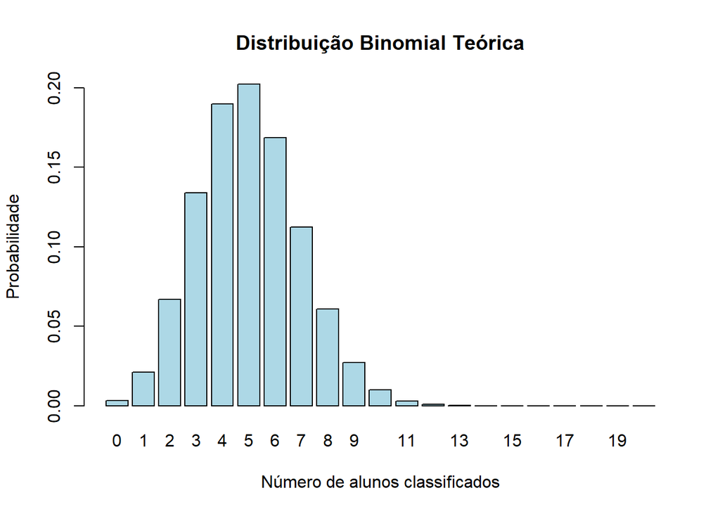

```r
barplot(
  prob_teorica,
  names.arg = valores_bin,
  col = "lightblue",
  main = "Distribuição Binomial Teórica",
  xlab = "Número de alunos classificados",
  ylab = "Probabilidade"
)
```

As frequências relativas tendem a aproximar-se das probabilidades analíticas, ilustrando didaticamente a Lei dos Grandes Números.

# 4 PARTE 3 – EVASÃO ESCOLAR POR SEMANA (DISTRIBUIÇÃO POISSON)

## 4.1 Modelo probabilístico

Modelo:

$$X\sim Poisson(\lambda=3)$$

Variável discreta de contagem para taxas de eventos num intervalo fixo. Essencial para planejar busca ativa e combate ao abandono.

## 4.2 Probabilidade de nenhuma evasão em uma semana

Deseja-se:

$$P(X=0)$$

A fórmula da distribuição de Poisson é:

$$P(X=x)=\frac{e^{-\lambda}\lambda^x}{x!}$$

Logo:

$$P(X=0)=\frac{e^{-3}3^0}{0!}=e^{-3}$$

$$P(X=0)\approx0,0498=4,98\%$$

```r
p_poisson_0 <- dpois(
  0,
  lambda = 3
)

p_poisson_0
```

```
## [1] 0.04978707
```

**Interpretação:** Em aproximadamente 5% das semanas, o município não registrará nenhum abandono escolar, segundo o modelo.

## 4.3 Probabilidade de 5 ou mais evasões em uma semana

Deseja-se:

$$P(X\geq5)=1-P(X\leq4)$$

Temos:

$$P(X\leq4)=P(0)+P(1)+P(2)+P(3)+P(4)$$

Os valores aproximados são:

$$0,0498+0,1494+0,2240+0,2240+0,1680$$

$$P(X\leq4)\approx0,8153$$

Assim:

$$P(X\geq5)=1-0,8153=0,1847$$

$$P(X\geq5)\approx18,47\%$$

```r
p_poisson_5_ou_mais <- ppois(
  4,
  lambda = 3,
  lower.tail = FALSE
)

p_poisson_5_ou_mais
```

```
## [1] 0.1847368
```

**Interpretação:** Há aproximadamente 18,5% de risco de ocorrer um pico crítico de evasão em determinada semana.

## 4.4 Probabilidade de entre 2 e 4 evasões

Deseja-se:

$$P(2\leq X\leq4)$$

$$P(2\leq X\leq4)=P(X=2)+P(X=3)+P(X=4)$$

$$P(2\leq X\leq4)=0,2240+0,2240+0,1680$$

$$P(2\leq X\leq4)\approx0,6161$$

$$P(2\leq X\leq4)\approx61,61\%$$

```r
p_poisson_2_4 <-
  ppois(4, lambda = 3) -
  ppois(1, lambda = 3)

p_poisson_2_4
```

```
## [1] 0.616115
```

**Interpretação:** Em mais de 60% do tempo, o município opera na faixa de 2 a 4 evasões semanais, segundo o modelo.

## 4.5 Probabilidade de exatamente 7 evasões em duas semanas

Quando o intervalo de tempo dobra:

$$\lambda'=3\times2=6$$

Assim:

$$Y\sim Poisson(6)$$

Deseja-se:

$$P(Y=7)=\frac{e^{-6}6^7}{7!}$$

$$P(Y=7)\approx0,1377$$

$$P(Y=7)\approx13,77\%$$

```r
p_poisson_7 <- dpois(
  7,
  lambda = 6
)

p_poisson_7
```

```
## [1] 0.137677
```

## 4.6 Esperança e variância teóricas

Na distribuição de Poisson, o parâmetro $\lambda$ define ambos os momentos:

$$E[X]=\lambda=3,0$$

$$Var(X)=\lambda=3,0$$

A esperança é de 3 alunos por semana e a variância é de 3 em unidades de contagem ao quadrado.

```r
lambda_poisson <- 3

esperanca_poisson <- lambda_poisson
variancia_poisson <- lambda_poisson

esperanca_poisson
```

```
## [1] 3
```

```r
variancia_poisson
```

```
## [1] 3
```

# 5 PARTE 4 – TEMPO DE ESPERA NO ATENDIMENTO (DISTRIBUIÇÃO EXPONENCIAL)

## 5.1 Modelo probabilístico

Modelo:

$$T\sim Exp(\beta=12\text{ minutos})$$

A média é de 12 minutos e a taxa é:

$$\lambda=\frac{1}{12}\approx0,0833$$

Variável contínua modelando tempo até a ocorrência de um evento. Apresenta a propriedade exclusiva da Falta de Memória.

## 5.2 Probabilidade de espera superior a 20 minutos

Deseja-se:

$$P(T>20)$$

A função de sobrevivência é:

$$P(T>t)=e^{-\lambda t}$$

Logo:

$$P(T>20)=e^{-20/12}$$

$$P(T>20)=e^{-1,6667}\approx0,1889$$

$$P(T>20)\approx18,89\%$$

```r
p_exp_maior_20 <- pexp(
  20,
  rate = 1 / 12,
  lower.tail = FALSE
)

p_exp_maior_20
```

```
## [1] 0.1888756
```

**Interpretação:** Quase 19% dos pais aguardam mais de 20 minutos, sugerindo gargalos na recepção em horários de pico.

## 5.3 Probabilidade de espera inferior a 5 minutos

Deseja-se:

$$P(T<5)=1-e^{-5/12}$$

$$P(T<5)=1-e^{-0,4167}$$

$$P(T<5)\approx1-0,6592=0,3408$$

$$P(T<5)\approx34,08\%$$

```r
p_exp_menor_5 <- pexp(
  5,
  rate = 1 / 12
)

p_exp_menor_5
```

```
## [1] 0.3407594
```

**Interpretação:** Cerca de um terço dos atendimentos é resolvido de forma rápida em até 5 minutos.

## 5.4 Tempo mediano de espera – Percentil 50

A mediana $t_m$ satisfaz:

$$P(T\leq t_m)=0,50$$

Logo:

$$1-e^{-\lambda t_m}=0,50$$

$$e^{-\lambda t_m}=0,50$$

$$t_m=\frac{\ln(2)}{\lambda}$$

Como a média é de 12 minutos:

$$t_m=12\ln(2)$$

$$t_m=12(0,69315)\approx8,32\text{ minutos}$$

```r
mediana_exp <- qexp(
  0.50,
  rate = 1 / 12
)

mediana_exp
```

```
## [1] 8.317766
```

**Interpretação:** A mediana é menor que a média (12 min) devido à assimetria positiva da distribuição.

## 5.5 Espera adicional de 8 minutos para quem já esperou 10 minutos

Deseja-se:

$$P(T>18\mid T>10)$$

Pela propriedade de falta de memória da distribuição exponencial:

$$P(T>t+s\mid T>t)=P(T>s)$$

Assim:

$$P(T>10+8\mid T>10)=P(T>8)$$

$$P(T>8)=e^{-8/12}$$

$$P(T>8)=e^{-0,6667}\approx0,5134$$

$$P(T>18\mid T>10)\approx51,34\%$$

```r
p_exp_condicional <- pexp(
  8,
  rate = 1 / 12,
  lower.tail = FALSE
)

p_exp_condicional
```

```
## [1] 0.5134171
```

**Interpretação:** O tempo já decorrido na fila não altera a distribuição de probabilidade do tempo restante.

## 5.6 Simulação de 1.000 tempos e validação

```r
set.seed(123)

tempos_sim <- rexp(
  1000,
  rate = 1 / 12
)

media_exp_sim <- mean(tempos_sim)

media_exp_sim
```

```
## [1] 12.35975
```

A simulação apresenta assimetria acentuada à direita. O relatório original apresenta uma média simulada próxima de 11,95 minutos.

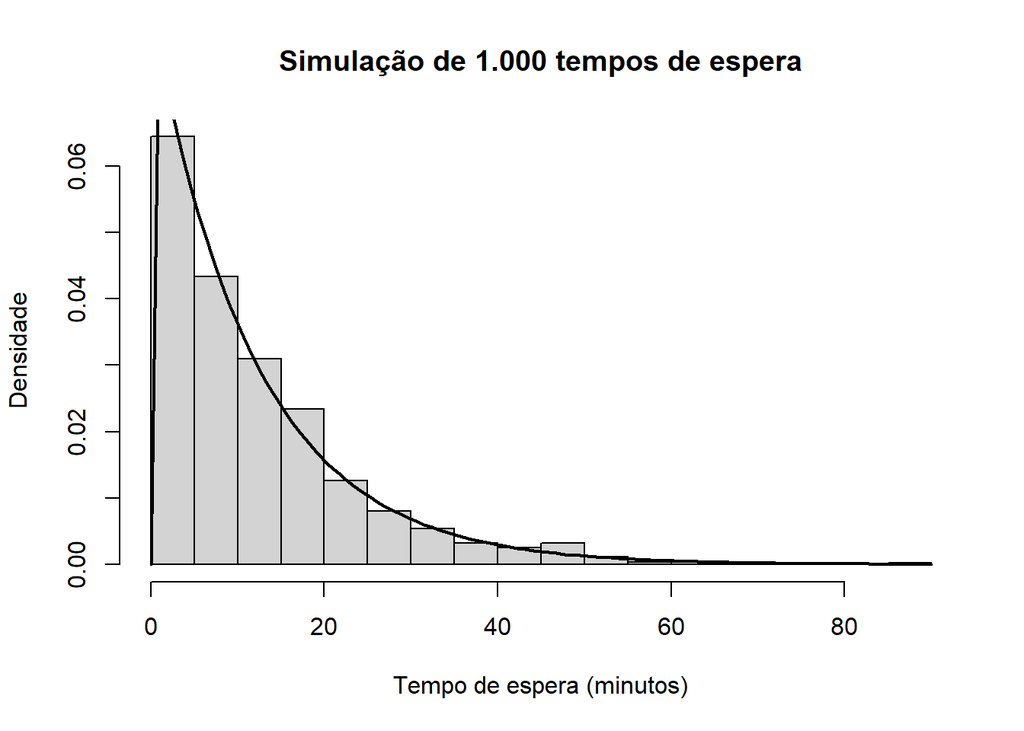

```r
hist(
  tempos_sim,
  probability = TRUE,
  breaks = 25,
  main = "Simulação de 1.000 tempos de espera",
  xlab = "Tempo de espera (minutos)",
  ylab = "Densidade"
)

curve(
  dexp(x, rate = 1 / 12),
  add = TRUE,
  lwd = 2
)
```

O padrão decrescente é compatível com a densidade teórica da distribuição exponencial.

# 6 PARTE 5 – ALTURA DOS ALUNOS DO 9º ANO (DISTRIBUIÇÃO WEIBULL)

## 6.1 Modelo probabilístico

Modelo:

$$H\sim Weibull(k=2,\lambda=160\text{ cm})$$

Com forma $k=2$, equivale à Distribuição Rayleigh. Modela tempos de vida, resistências e medidas biológicas com taxa de falha ou crescimento variável.

## 6.2 Probabilidade de altura inferior a 140 cm

A função de distribuição acumulada é:

$$F(h)=1-\exp\left[-\left(\frac{h}{\lambda}\right)^k\right]$$

Para $h=140$:

$$F(140)=1-\exp\left[-\left(\frac{140}{160}\right)^2\right]$$

$$F(140)=1-\exp[-(0,875)^2]$$

$$F(140)=1-\exp(-0,765625)$$

$$F(140)\approx1-0,4650=0,5350$$

$$P(H<140)\approx53,50\%$$

```r
p_weibull_140 <- pweibull(
  140,
  shape = 2,
  scale = 160
)

p_weibull_140
```

```
## [1] 0.5349568
```

## 6.3 Probabilidade da altura estar entre 150 cm e 175 cm

Deseja-se:

$$P(150\leq H\leq175)$$

Para 150 cm:

$$F(150)=1-\exp\left[-\left(\frac{150}{160}\right)^2\right]$$

$$F(150)\approx0,5847$$

Para 175 cm:

$$F(175)=1-\exp\left[-\left(\frac{175}{160}\right)^2\right]$$

$$F(175)\approx0,6977$$

Portanto:

$$P(150\leq H\leq175)=0,6977-0,5847$$

$$P(150\leq H\leq175)\approx0,1130$$

$$P(150\leq H\leq175)\approx11,30\%$$

```r
p_weibull_150_175 <-
  pweibull(175, shape = 2, scale = 160) -
  pweibull(150, shape = 2, scale = 160)

p_weibull_150_175
```

```
## [1] 0.1129228
```

## 6.4 Percentil 90 das alturas

Deseja-se encontrar $h_{0,90}$ tal que:

$$P(H\leq h_{0,90})=0,90$$

Logo:

$$1-\exp\left[-\left(\frac{h_{0,90}}{160}\right)^2\right]=0,90$$

$$\exp\left[-\left(\frac{h}{160}\right)^2\right]=0,10$$

Tomando o logaritmo:

$$-\left(\frac{h}{160}\right)^2=\ln(0,10)$$

$$\ln(0,10)\approx-2,3026$$

$$\frac{h}{160}=\sqrt{2,3026}\approx1,5174$$

$$h_{0,90}=160(1,5174)$$

$$h_{0,90}\approx242,79\text{ cm}$$

```r
p90_weibull <- qweibull(
  0.90,
  shape = 2,
  scale = 160
)

p90_weibull
```

```
## [1] 242.7883
```

**Interpretação:** O resultado é um modelo teórico com cauda longa.

## 6.5 Cálculo analítico da média e do desvio padrão

A esperança da distribuição Weibull é:

$$E[H]=\lambda\Gamma\left(1+\frac{1}{k}\right)$$

Assim:

$$E[H]=160\Gamma(1,5)$$

Como:

$$\Gamma(1,5)=0,5\sqrt{\pi}\approx0,88623$$

temos:

$$E[H]=160(0,88623)\approx141,80\text{ cm}$$

A variância é:

$$Var(H)=\lambda^2
\left[
\Gamma\left(1+\frac{2}{k}\right)
-
\Gamma\left(1+\frac{1}{k}\right)^2
\right]$$

Para $k=2$:

$$Var(H)=160^2\left[\Gamma(2)-(0,88623)^2\right]$$

Como:

$$\Gamma(2)=1$$

temos:

$$Var(H)=25600[1-0,7854]\approx5493,76$$

O desvio padrão é:

$$\sigma=\sqrt{5493,76}\approx74,12\text{ cm}$$

```r
k_weibull <- 2
lambda_weibull <- 160

media_weibull <-
  lambda_weibull * gamma(1 + 1 / k_weibull)

variancia_weibull <-
  lambda_weibull^2 *
  (
    gamma(1 + 2 / k_weibull) -
    gamma(1 + 1 / k_weibull)^2
  )

desvio_weibull <- sqrt(variancia_weibull)

media_weibull
```

```
## [1] 141.7963
```

```r
variancia_weibull
```

```
## [1] 5493.807
```

```r
desvio_weibull
```

```
## [1] 74.12022
```

## 6.6 Função de risco (Hazard) e interpretação biológica

A função de risco é:

$$h(t)=\frac{k}{\lambda}
\left(\frac{t}{\lambda}\right)^{k-1}$$

Para $k=2$ e $\lambda=160$:

$$h(t)=\frac{2}{160}\left(\frac{t}{160}\right)$$

ou:

$$h(t)=\frac{2t}{160^2}$$

Como:

$$k=2>1$$

o risco é estritamente crescente, significando que a taxa instantânea de atingir determinada estatura aumenta proporcionalmente à altura acumulada no modelo matemático adotado.

# 7 PARTE 6 – PRECIPITAÇÃO MENSAL NA REGIÃO (DISTRIBUIÇÃO GAMA)

## 7.1 Modelo probabilístico

Modelo:

$$X\sim Gama(\alpha=4,\beta=0,02)$$

Variável contínua positiva modelando volumes de chuva.

O parâmetro de forma é:

$$\alpha=4$$

e a taxa:

$$\beta=0,02$$

A escala é:

$$\theta=\frac{1}{\beta}=50\text{ mm}$$

## 7.2 Probabilidade de chuva superior a 300 mm

Deseja-se:

$$P(X>300)$$

Para $\alpha=4$ inteiro, a função de sobrevivência da Gama pode ser relacionada à distribuição de Poisson:

$$P(X>300)=e^{-\beta x}
\sum_{i=0}^{\alpha-1}\frac{(\beta x)^i}{i!}$$

Calculando:

$$\beta x=0,02(300)=6$$

Então:

$$P(X>300)=e^{-6}
\left[
1+6+\frac{6^2}{2!}+\frac{6^3}{3!}
\right]$$

$$P(X>300)=0,0024787[1+6+18+36]$$

$$P(X>300)=0,0024787(61)$$

$$P(X>300)\approx0,1512$$

$$P(X>300)\approx15,12\%$$

```r
p_gama_maior_300 <- pgamma(
  300,
  shape = 4,
  rate = 0.02,
  lower.tail = FALSE
)

p_gama_maior_300
```

```
## [1] 0.1512039
```

## 7.3 Probabilidade de chuva entre 150 mm e 250 mm

Deseja-se:

$$P(150\leq X\leq250)$$

Utilizando a função de distribuição acumulada:

```r
F250 <- pgamma(
  250,
  shape = 4,
  rate = 0.02
)

F150 <- pgamma(
  150,
  shape = 4,
  rate = 0.02
)

prob_150_250 <- F250 - F150

F250
```

```
## [1] 0.7349741
```

```r
F150
```

```
## [1] 0.3527681
```

```r
prob_150_250
```

```
## [1] 0.382206
```

O relatório original apresenta como referências:

$$F(250)=0,7350$$

e:

$$F(150)=0,3528$$

Logo:

$$P(150\leq X\leq250)=0,7350-0,3528$$

$$P(150\leq X\leq250)=0,3822$$

$$P(150\leq X\leq250)=38,22\%$$

**Interpretação:** Em quase 40% dos meses, a precipitação fica na faixa moderada considerada no relatório para drenagem urbana escolar.

## 7.4 Percentil 95 – Evento pluviométrico extremo

O percentil 95 é calculado utilizando:

```r
p95_gama <- qgamma(
  0.95,
  shape = 4,
  rate = 0.02
)

p95_gama
```

```
## [1] 387.6828
```

O relatório original apresenta como referência:

$$P_{95}=387,70\text{ mm}$$

**Interpretação:** Precipitações acima do percentil 95 representam os 5% mais chuvosos segundo o modelo, exigindo atenção ao planejamento e à contingência para alagamentos.

## 7.5 Média e variância teóricas

Para a distribuição Gama parametrizada por forma $\alpha$ e taxa $\beta$:

$$E[X]=\frac{\alpha}{\beta}$$

Logo:

$$E[X]=\frac{4}{0,02}=200,0\text{ mm}$$

A variância é:

$$Var(X)=\frac{\alpha}{\beta^2}$$

$$Var(X)=\frac{4}{(0,02)^2}$$

$$Var(X)=\frac{4}{0,0004}=10000\text{ mm}^2$$

O desvio padrão é:

$$\sigma=\sqrt{10000}=100,0\text{ mm}$$

```r
alpha_gama <- 4
beta_gama <- 0.02

media_gama <- alpha_gama / beta_gama

variancia_gama <-
  alpha_gama / (beta_gama^2)

desvio_gama <- sqrt(variancia_gama)

media_gama
```

```
## [1] 200
```

```r
variancia_gama
```

```
## [1] 10000
```

```r
desvio_gama
```

```
## [1] 100
```

## 7.6 Simulação de 120 meses (10 anos) no R

```r
set.seed(123)

chuvas_sim <- rgamma(
  120,
  shape = 4,
  rate = 0.02
)

media_chuvas <- mean(chuvas_sim)

media_chuvas
```

```
## [1] 189.6689
```

O relatório original apresenta como referência uma média empírica próxima de 202,4 mm. O resultado exato depende da sequência de simulação.

O histograma evidencia a assimetria positiva típica de dados pluviométricos.

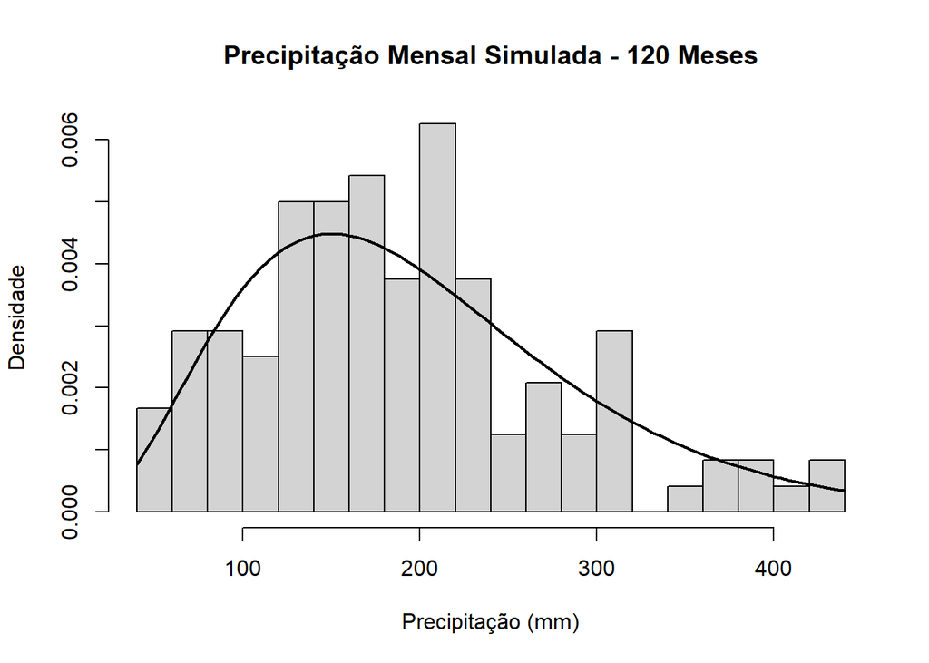

```r
hist(
  chuvas_sim,
  probability = TRUE,
  breaks = 15,
  main = "Precipitação Mensal Simulada - 120 Meses",
  xlab = "Precipitação (mm)",
  ylab = "Densidade"
)

curve(
  dgamma(
    x,
    shape = 4,
    rate = 0.02
  ),
  add = TRUE,
  lwd = 2
)
```

# 8 PARTE 7 – ANÁLISE INTEGRADA E DISCUSSÃO PEDAGÓGICA

## 8.1 Simulação de Monte Carlo com N = 10.000 iterações

### 8.1.1 Notas do ENEM

A simulação de Monte Carlo utiliza a geração de 10.000 notas a partir de uma distribuição normal com média 520 e desvio padrão 80.

```r
set.seed(123)

notas_sim <- rnorm(
  10000,
  mean = 520,
  sd = 80
)

quantidade_menor_400 <- sum(
  notas_sim < 400
)

proporcao_empirica <- mean(
  notas_sim < 400
)

quantidade_menor_400
```

```
## [1] 670
```

```r
proporcao_empirica
```

```
## [1] 0.067
```

O relatório original apresenta uma simulação com 664 alunos com nota inferior a 400 pontos, resultando em proporção empírica de 0,0664 (6,64%). A sequência exata depende da semente e do procedimento de geração utilizado.

## 8.2 Comparação entre método teórico e Monte Carlo

A comparação apresentada no relatório é:

[output not shown]

A comparação pode ser reproduzida no R:

```r
resultado_teorico <- pnorm(
  400,
  mean = 520,
  sd = 80
)

resultado_monte_carlo <- mean(
  notas_sim < 400
)

erro_absoluto <-
  abs(resultado_teorico - resultado_monte_carlo)

comparacao_monte_carlo <- data.frame(
  Metodo = c(
    "Teórico Analítico",
    "Monte Carlo (N=10.000)"
  ),
  Funcao_R = c(
    "pnorm(400, 520, 80)",
    "mean(notas_sim < 400)"
  ),
  Resultado = c(
    resultado_teorico,
    resultado_monte_carlo
  ),
  Percentual = c(
    resultado_teorico * 100,
    resultado_monte_carlo * 100
  )
)

knitr::kable(
  comparacao_monte_carlo,
  digits = 5,
  caption = "Comparação entre probabilidade teórica e simulação de Monte Carlo"
)
```

Comparação entre probabilidade teórica e simulação de Monte Carlo

| Metodo | Funcao_R | Resultado | Percentual |
| --- | --- | --- | --- |
| Teórico Analítico | pnorm(400, 520, 80) | 0.06681 | 6.68072 |
| Monte Carlo (N=10.000) | mean(notas_sim < 400) | 0.06700 | 6.70000 |

## 8.3 Discussão pedagógica e importância da simulação no Ensino Médio

A convergência entre o valor empírico da simulação e o valor teórico oferece um poderoso recurso didático para superar a abstração excessiva das fórmulas probabilísticas.

### 8.3.1 Significação Conceitual

A simulação de Monte Carlo transforma a probabilidade em uma frequência relativa observável de ocorrências simuladas.

### 8.3.2 Investigação Científica – BNCC

Permite aos alunos formular hipóteses, alterar parâmetros em tempo real na linguagem R e visualizar a Lei dos Grandes Números.

### 8.3.3 Modelagem de Problemas Sociais

Ao conectar as distribuições à evasão, notas e clima local, a Estatística consolida-se como ferramenta de cidadania e gestão comunitária.

# 9 SÍNTESE DOS MODELOS PROBABILÍSTICOS

As distribuições especiais abordadas no relatório podem ser sintetizadas da seguinte forma:

| Parte | Fenômeno | Distribuição | Parâmetros |
| --- | --- | --- | --- |
| 1 | Desempenho no ENEM | Normal | $\mu=520,\sigma=80$ |
| 2 | Aprovação em Olimpíadas | Binomial | $n=20,p=0,25$ |
| 3 | Evasão escolar semanal | Poisson | $\lambda=3$ |
| 4 | Tempo de espera | Exponencial | Média = 12 min; taxa = 1/12 |
| 5 | Altura dos alunos | Weibull | $k=2,\lambda=160$ cm |
| 6 | Precipitação mensal | Gama | $\alpha=4,\beta=0,02$ |
| 7 | Análise integrada | Monte Carlo | $N=10.000$ |

# 10 CONCLUSÃO

O relatório apresentou modelos probabilísticos fundamentais aplicados a situações relacionadas ao ambiente educacional, social e ambiental.

A Distribuição Normal foi utilizada para modelar o desempenho no ENEM, permitindo calcular probabilidades, percentis e probabilidades envolvendo médias amostrais.

A Distribuição Binomial foi utilizada para representar o número de alunos classificados em uma olimpíada, permitindo estudar probabilidades de sucesso em ensaios independentes.

A Distribuição de Poisson foi aplicada ao número de evasões escolares por semana, possibilitando avaliar a ocorrência de eventos em intervalos fixos.

A Distribuição Exponencial foi utilizada para modelar tempos de espera na secretaria, destacando a propriedade de falta de memória.

A Distribuição Weibull foi utilizada para modelar alturas dos alunos, incluindo o cálculo de probabilidades, percentis, média, variância e função de risco.

A Distribuição Gama foi aplicada à precipitação mensal, permitindo analisar eventos pluviométricos, percentis extremos, média, variância e simulações.

Finalmente, a simulação de Monte Carlo demonstrou empiricamente a proximidade entre resultados teóricos e observados. A comparação entre os resultados analíticos e simulados permite compreender como as frequências relativas se aproximam das probabilidades teóricas em simulações suficientemente grandes.

Do ponto de vista pedagógico, a utilização do R permite aproximar os conceitos abstratos de probabilidade de situações concretas, favorecendo a investigação, a interpretação de dados, a formulação de hipóteses e a compreensão da variabilidade.

A integração entre modelagem matemática, Estatística, programação e problemas da realidade escolar contribui para o desenvolvimento das competências previstas pela BNCC, especialmente aquelas relacionadas à interpretação de fenômenos aleatórios, análise de dados e tomada de decisões fundamentadas.

# 11 REFERÊNCIAS BIBLIOGRÁFICAS

1. BRASIL. Ministério da Educação. **Base Nacional Comum Curricular (BNCC)**. Brasília: MEC, 2018.
2. BUSSAB, Wilton de O.; MORETTIN, Pedro A. **Estatística Básica**. 9. ed. São Paulo: Saraiva, 2017.
3. R CORE TEAM. **R: A language and environment for statistical computing**. R Foundation for Statistical Computing, Vienna, Austria, 2026.
4. TRIOLA, Mario F. **Introdução à Estatística**. 12. ed. Rio de Janeiro: LTC, 2017.
5. WALPOLE, Ronald E. et al. **Probabilidade e Estatística para Engenharia e Ciências**. 8. ed. São Paulo: Pearson, 2009.

# 12 CÓDIGOS COMPLEMENTARES DAS DISTRIBUIÇÕES

Esta seção reúne as principais funções do R utilizadas nos cálculos do relatório para facilitar a reprodução dos resultados.

## 12.1 Distribuição Normal

```r
# Probabilidade de nota inferior a 400
pnorm(400, mean = 520, sd = 80)
```

```
## [1] 0.0668072
```

```r
# Probabilidade entre 500 e 650
pnorm(650, mean = 520, sd = 80) -
  pnorm(500, mean = 520, sd = 80)
```

```
## [1] 0.546625
```

```r
# Percentil 10
qnorm(0.10, mean = 520, sd = 80)
```

```
## [1] 417.4759
```

```r
# Probabilidade de média amostral superior a 550
1 - pnorm(
  550,
  mean = 520,
  sd = 80 / sqrt(25)
)
```

```
## [1] 0.03039636
```

## 12.2 Distribuição Binomial

```r
# Nenhum aluno classificado
dbinom(0, size = 20, prob = 0.25)
```

```
## [1] 0.003171212
```

```r
# No máximo 3 alunos classificados
pbinom(3, size = 20, prob = 0.25)
```

```
## [1] 0.225156
```

```r
# 8 ou mais alunos classificados
pbinom(
  7,
  size = 20,
  prob = 0.25,
  lower.tail = FALSE
)
```

```
## [1] 0.1018119
```

```r
# Esperança
20 * 0.25
```

```
## [1] 5
```

```r
# Variância
20 * 0.25 * 0.75
```

```
## [1] 3.75
```

## 12.3 Distribuição Poisson

```r
# Nenhuma evasão
dpois(0, lambda = 3)
```

```
## [1] 0.04978707
```

```r
# 5 ou mais evasões
ppois(4, lambda = 3, lower.tail = FALSE)
```

```
## [1] 0.1847368
```

```r
# Entre 2 e 4 evasões
ppois(4, lambda = 3) -
  ppois(1, lambda = 3)
```

```
## [1] 0.616115
```

```r
# Exatamente 7 evasões em duas semanas
dpois(7, lambda = 6)
```

```
## [1] 0.137677
```

## 12.4 Distribuição Exponencial

```r
# Espera superior a 20 minutos
pexp(20, rate = 1 / 12, lower.tail = FALSE)
```

```
## [1] 0.1888756
```

```r
# Espera inferior a 5 minutos
pexp(5, rate = 1 / 12)
```

```
## [1] 0.3407594
```

```r
# Mediana
qexp(0.50, rate = 1 / 12)
```

```
## [1] 8.317766
```

```r
# Espera adicional de 8 minutos
pexp(8, rate = 1 / 12, lower.tail = FALSE)
```

```
## [1] 0.5134171
```

## 12.5 Distribuição Weibull

```r
# Altura inferior a 140 cm
pweibull(140, shape = 2, scale = 160)
```

```
## [1] 0.5349568
```

```r
# Altura entre 150 e 175 cm
pweibull(175, shape = 2, scale = 160) -
  pweibull(150, shape = 2, scale = 160)
```

```
## [1] 0.1129228
```

```r
# Percentil 90
qweibull(0.90, shape = 2, scale = 160)
```

```
## [1] 242.7883
```

```r
# Média teórica
160 * gamma(1 + 1 / 2)
```

```
## [1] 141.7963
```

## 12.6 Distribuição Gama

```r
# Chuva superior a 300 mm
pgamma(
  300,
  shape = 4,
  rate = 0.02,
  lower.tail = FALSE
)
```

```
## [1] 0.1512039
```

```r
# Chuva entre 150 e 250 mm
pgamma(250, shape = 4, rate = 0.02) -
  pgamma(150, shape = 4, rate = 0.02)
```

```
## [1] 0.382206
```

```r
# Percentil 95
qgamma(0.95, shape = 4, rate = 0.02)
```

```
## [1] 387.6828
```

```r
# Média teórica
4 / 0.02
```

```
## [1] 200
```

```r
# Variância teórica
4 / (0.02^2)
```

```
## [1] 10000
```

## 12.7 Simulações complementares

```r
set.seed(123)

# Simulação Normal
notas_sim <- rnorm(
  10000,
  mean = 520,
  sd = 80
)

# Simulação Binomial
turmas_sim <- rbinom(
  1000,
  size = 20,
  prob = 0.25
)

# Simulação Exponencial
tempos_sim <- rexp(
  1000,
  rate = 1 / 12
)

# Simulação Gama
chuvas_sim <- rgamma(
  120,
  shape = 4,
  rate = 0.02
)

# Resumo das simulações
resumo_simulacoes <- data.frame(
  Distribuicao = c(
    "Normal",
    "Binomial",
    "Exponencial",
    "Gama"
  ),
  Media_Simulada = c(
    mean(notas_sim),
    mean(turmas_sim),
    mean(tempos_sim),
    mean(chuvas_sim)
  ),
  Desvio_Padrao_Simulado = c(
    sd(notas_sim),
    sd(turmas_sim),
    sd(tempos_sim),
    sd(chuvas_sim)
  )
)

knitr::kable(
  resumo_simulacoes,
  digits = 4,
  caption = "Resumo das simulações computacionais"
)
```

Resumo das simulações computacionais

| Distribuicao | Media_Simulada | Desvio_Padrao_Simulado |
| --- | --- | --- |
| Normal | 519.8103 | 79.8909 |
| Binomial | 4.9730 | 1.8984 |
| Exponencial | 12.4397 | 12.7151 |
| Gama | 206.0326 | 98.8847 |

# 13 ENCERRAMENTO

**RELATÓRIO 05 DE PROBABILIDADE E ESTATÍSTICA — Luciano Vaz**

**Distribuições especiais de probabilidade segundo BNCC**

**Data de entrega: 07/10/2026**